# The Role of Warmth and Competence Perceptions in Labor Market Outcomes - 3 Mixed effects of social perception on callback rates in correspondence studies manipulating social identity categories

Meta-analysis of k = 16 studies with o = 7830 observations using inverse variance method. Random effects model with restricted maximum-likelihood estimator for tau^2 and Hartung-Knapp adjustment (df = 15). Confidence intervals for tau^2 and tau estimated using Q-Profile method. Fisher's z transformation used for correlations.

Furthermore, we assessed the correlation between the warmth and competence ratings and found that the Pearson correlation index ($\rho$) was significant for most studies, with a pooled correlation of $\hat{\rho}$ = 0.595 (p = 0, Table S5).

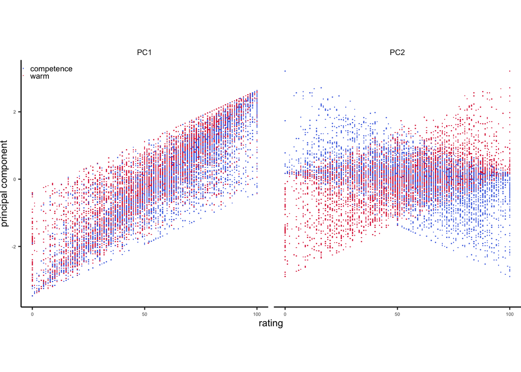

Fig. 3C: Scatter plots of category-specific warmth and competence ratings showing the structure of PC1 and PC2.

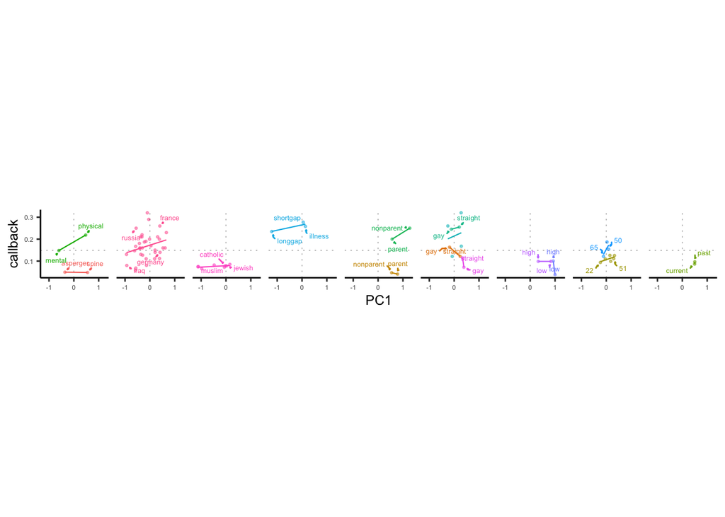

```
Running 1000 iterations for an approximate permutation test.
```

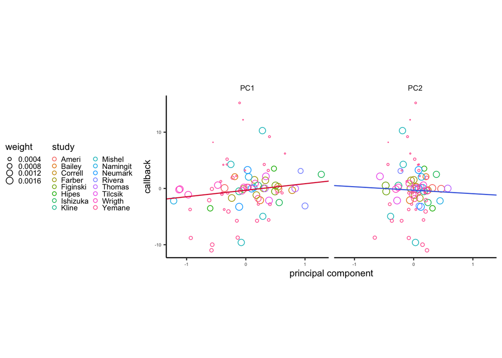

Fig. 3D: Meta-regression of PC1 and PC2 on callback, where each circle identifies a signal by study; the circle size indicates the assigned weight in the meta-regression. Lines indicate fitted intercepts and betas.

Table S7. Estimates of linear models of PC1 on callback by category

|  | estimate | std.error | statistic | p.value |
| --- | --- | --- | --- | --- |
| wealth |  |  |  |  |
| rivera | -0.84 | NaN | NaN | NaN |
| thomas | 0.00 | NaN | NaN | NaN |
| unemployed |  |  |  |  |
| namingit | 0.02 | 0.01 | 1.74 | 0.33 |
| sexuality |  |  |  |  |
| bailey | -0.10 | NaN | NaN | NaN |
| kline | 0.03 | NaN | NaN | NaN |
| mishel | 0.05 | 0.23 | 0.22 | 0.85 |
| tilcsik | -0.82 | NaN | NaN | NaN |
| parenthood |  |  |  |  |
| correll | -0.03 | NaN | NaN | NaN |
| ishizuka | 0.07 | NaN | NaN | NaN |
| nationality |  |  |  |  |
| yemane | 0.04 | 0.02 | 1.52 | 0.14 |
| military |  |  |  |  |
| figinski | 1.41 | NaN | NaN | NaN |
| health |  |  |  |  |
| ameri | 0.00 | NaN | NaN | NaN |
| hipes | 0.07 | NaN | NaN | NaN |
| age |  |  |  |  |
| farber | 0.04 | 0.02 | 1.63 | 0.18 |
| neumark | 0.20 | 0.23 | 0.87 | 0.54 |
| wrigth | 0.01 | 0.00 | 1.68 | 0.14 |

The meta-regression did not yield a significant overall effect. Therefore, we explored the relationship between PC1 and callback by category. Given the limited number of levels across categories (Figure 3B), it was not possible to calculate a meaningful effect size directly relating ratings to callback at the study level. Thus, we present a graphical representation in Figure 3B, with lines representing fitted linear models for each study (Table S7). For some categories, the relation between callback and PC1 is positive (e.g., nationality, which also samples a larger number—35—of categories). For most other categories, however, such as wealth, sexuality, and parenthood, there are both positive and negative slopes in different studies. Under the category of sexuality, slope signs in four studies were equally split between positive and negative, which is especially striking given the large range of ICCs across signals.